# The Impact of Mercedes-Benz Stadium on Crime in Atlanta Neighborhoods

- Show All Code
- Hide All Code
- View Source

A Difference-in-Differences Analysis

Author

Affiliation

Karan Mandair

Old Dominion University

## Introduction

Large sports venues are major infrastructure investments, costing billions of dollars and reshape urban neighborhoods in complex ways. These venues can bring increased economic activity and development, but can also bring increased crime, congestion, and neighborhood decline. Therefore, understanding the actual crime impacts of major sports venues is crucial, for urban planning, public safety policy, and how cities evaluate billion-dollar stadium projects.

This paper examines whether the opening of Mercedes-Benz Stadium affected crime patterns in Atlanta neighborhoods. The stadium opened on August 26, 2017, replacing the Georgia Dome as home to the NFL’s Atlanta Falcons and MLS’s Atlanta United. With 71,000 seats and around 75 events per year, the stadium brings in massive crowds to downtown Atlanta for football games, soccer matches, and other events.

I use a difference-in-differences research design with daily crime data from 2013-2019 to estimate how the stadium affected local crime. I compare crime trends in census tracts within 2 kilometers of the stadium (treatment group) to trends in tracts 3-6 kilometers away (control group). This approach lets me separate two different questions: Did the stadium permanently change crime rates in nearby neighborhoods? And do stadium events temporarily spike crime on game days?

The results show several clear findings. Opening the stadium didn’t permanently change crime rates in nearby neighborhoods. Areas close to the stadium saw the same crime trends as areas further away, which shows that the stadium didn’t make nearby neighborhoods more dangerous. Furthermore, crime increases on game days in both neighborhoods near and far from the stadium. When the stadium hosts sporting events, crime increases by about 0.69 crimes per census tract throughout the entire study area. Before the stadium opened, crime trends in both areas were moving together in parallel, which supports the research design and the underlying assumption of parallel trends. After opening, the differences between areas remains small and statistically insignificant, confirming there is no real localized crime effects, of having the stadium nearby.

These findings give practical implications. One of the findings from this paper is that stadiums don’t appear to harm nearby neighborhoods through permanent crime increases. This is a positive as this is a main concern that is brought up by residents and community groups. However, crime effects appear to increase citywide on event days. This suggests police departments should spread resources throughout all areas on game days, rather than concentrating them only around the stadium.

The paper follows as such: Section 2 reviews related literature on sports venues and crime, Section 3 describes the data and spatial analysis, Section 4 outlines the difference-in-differences methodology, Section 5 presents the main results and robustness checks, and Section 6 concludes with policy implications and directions for future research.

## Literature Review

### Sports Venues and Local Crime

The relationship between sports venues and crime has been studied heavily. Research shows consistently that sporting events create conditions that increase crime, but the spatial distribution and permanent effects give mixed results.

A number of studies have been done relating to why sports venues might increase crime. Routine activity theory (Cohen and Felson, 1979) suggests that sporting events create perfect conditions for crime. These include three key conditions: motivated offenders, attractive targets (wealthy fans), and reduced guardianship (crowds provide cover). Moreover, Card and Dahl (2011) find that unexpected losses by NFL teams lead to increases in at home male-on-female partner violence. Furthermore, Rees and Schnepel (2009) work shows increases in assaults, vandalism, and arrests for disorderly conduct on college football game days. Marie (2016) shows that football matches in the UK increase property crime, with theft rising by approximately 7% for every additional 10,000 spectators. Large crowds from sporting venues also create create situations for vehicle-related crimes, in regards to parking areas.

Studies about spatial patterns have also been carried out. Recent research emphasizes the importance of spatial analysis in understanding stadium crime impacts. Billings and Depken (2011) examine two venues in Charlotte, North Carolina and find no overall city-wide increase in crime, but find a significant spatial redistribution—crime increases within half a mile of venues on event days. However, their results actually show crime decreases in areas further away. Kurland et al. (2014) analyze crime patterns around Wembley Stadium in London using a natural experiment approach, finding that crime rates increase on event days more so in areas closer to the stadium. These studies highlight that aggregated city-level data may hide important spatial relationships in how stadiums affect crime in areas both close, and further away from the stadium.

Important gaps still remain regarding sports venues and crime. While recent studies have made progress in understanding stadium crime impacts, several gaps remain. Kurland et al. (2014) and Vandeviver et al. (2019) examine spatial and temporal patterns around stadiums, focusing on single venues in Europe and stadium closures. Billings and Depken (2011) find crime displacement patterns but examine short-term event effects rather than permanent neighborhood changes. The research in the field mainly examines either temporary event-day effects or permanent neighborhood changes, but rarely both at the same time with a proper control group. Studies typically ask “Does crime increase on game days?” (Kurland et al., 2014) or “What happens when a stadium closes?” (Vandeviver et al., 2019), but not whether new stadium openings create differential crime impacts in nearby versus distant neighborhoods. My analysis contributes by examining both permanent and temporary effects of a major stadium opening using a triple difference specification with daily panel data across multiple neighborhoods, which allows me to test whether event-day crime impacts changed differently for areas near the stadium.

### Difference-in-Differences in Crime Research

The difference-in-differences methodology has become used extensively in evaluating how policies and infrastructure affect crime. The approach compares changes in outcomes between treated and control groups before and after an intervention, controlling for both time-invariant differences between areas and common time trends.

Recent research shows versatility of DiD in crime research. MacDonald et al. (2016) use it to study police deployment effects, Priks (2015) examines surveillance camera impacts, and Ellen et al. (2013) evaluate how foreclosures affect neighborhood crime. Vandeviver et al. (2019) apply DiD to study what happens when a stadium closes in Belgium, finding evidence of both immediate event-day effects and delayed exploitation of criminal opportunities. The key underlying assumption is the parallel trends assumption, which states that treatment and control areas would follow similar trends without the intervention.

My analysis applies DiD to a stadium opening with several advantages: a clear treatment date (August 26, 2017), well-defined geographic boundaries (census tracts around the stadium), and significant daily-level data over multiple years. This setup allows me to separately estimate permanent neighborhood effects and temporary event-day effects.

### Gap in the Literature

Despite billions of dollars in public investment in sports infrastructure, the causal evidence on stadium crime impacts remains somewhat limited. Existing studies typically have one or more of these limitations. One limitation is just a focus on temporary effects only, with most research examining crime on game days, but ignoring whether stadiums permanently change surrounding neighborhoods. Another is a lack of proper control groups without comparison areas, which essentially makes it impossible to separate stadium effects from other trends. Additionally, the use of aggregated data as city-level or large-area analyses cannot separate whether effects are concentrated near stadiums, or spread out across the city.

My analysis addresses all three limitations. I use census tract-level data to distinguish localized from city-wide effects, I employ a clear control group (areas 3-6km away) with a buffer zone to contain spill over effects(2-3km), and I examine both permanent and temporary effects using daily crime data over seven years. This approach provides clearer evidence on whether a stadium’s actual location matters in regards to crime, or whether event-day effects spread broadly across the city.

## Data

### Data Sources

This analysis combines three primary data sources:

1. **Crime Data**: Atlanta Police Department incident-level crime reports (2013-2019) obtained from the Atlanta Police Department’s public records portal. The data include crime type, location coordinates, and report date/time for all reported crimes.
2. **Geographic Data**: U.S. Census Bureau TIGER/Line shapefiles defining census tract boundaries in Fulton County, Georgia (2019 vintage). Census tracts provide standardized geographic units for spatial analysis.
3. **Stadium Event Schedule**: Event dates and times for all NFL and MLS games at Mercedes-Benz Stadium (2017-2019), compiled from official team schedules. This includes 24 Atlanta Falcons games and 51 Atlanta United FC games.

### Sample Construction

```r
crime_clean <- crime_raw %>%
  rename(
    report_number = `Report Number`,
    date = `Report Date`,
    crime_type = `Crime Type`,
    occur_time = `Occur Time`
  ) %>%
  filter(!is.na(x) & !is.na(y)) %>%
  mutate(
    date_clean = mdy_hms(date),
    year = year(date_clean),
    month = month(date_clean),
    date_only = as_date(date_clean),
    post = if_else(date_clean >= as_datetime("2017-08-26 00:00:00"), 1, 0)
  ) %>%
  filter(year >= 2013 & year <= 2019)


crime_sf <- st_as_sf(crime_clean, coords = c("x", "y"), crs = 3857) %>%
  st_transform(crs = 2240)

crime_tracts_df <- st_join(crime_sf, tracts %>% select(GEOID, NAME),
                           join = st_nearest_feature) %>%
  st_drop_geometry() %>%
  rename(tract_id = GEOID)
```

I restrict the crime data to 2013-2019 to provide a balanced four-year pre-treatment window (2013-2017) and two-year post-treatment window (2017-2019). I do not include 2020 and beyond due to Covid-19 changes. This gives 200,748 crime incidents with valid geographic coordinates.

### Treatment and Control Group Definition

I define treatment groups based on distance from the stadium. I classify census tracts into three groups:

- **Treatment Group**: Tracts with centroids within 2 kilometers of Mercedes-Benz Stadium (N = 14)
- **Control Group**: Tracts with centroids between 3-6 kilometers from the stadium (N = 40)
- **Buffer Zone**: Tracts 2-3 kilometers away are excluded to have clean separation and address spillover effects.

This classification creates a “donut” design that avoids contamination while maintaining geographic proximity for comparability.

```r
stadium_coords <- st_sfc(st_point(c(-84.400644, 33.755313)), crs = 4326) %>%
  st_transform(crs = 2240)


tract_distances <- tracts %>%
  mutate(
    centroid = st_centroid(geometry),
    distance_km = as.numeric(st_distance(centroid, stadium_coords)) * 0.3048 / 1000,
    treatment_group = case_when(
      distance_km <= 2.0 ~ "treatment",
      distance_km > 3.0 & distance_km <= 6.0 ~ "control",
      TRUE ~ "buffer"
    ),
    treated = case_when(
      treatment_group == "treatment" ~ 1,
      treatment_group == "control" ~ 0,
      TRUE ~ NA_real_
    )
  ) %>%
  st_drop_geometry() %>%
  select(GEOID, distance_km, treatment_group, treated)
```

Figure 1 displays the spatial distribution of treatment and control tracts. The treatment area (orange) forms a tight ring around the stadium location (red diamond), while control tracts (blue) consists of the broader surrounding area.

```r
tracts_for_map <- tracts %>%
  left_join(tract_distances, by = "GEOID") %>%
  filter(!is.na(treated))


ring_2km <- st_buffer(stadium_coords, 2000 / 0.3048)
ring_3km <- st_buffer(stadium_coords, 3000 / 0.3048)
ring_6km <- st_buffer(stadium_coords, 6000 / 0.3048)


ggplot() +
  geom_sf(data = ring_6km, fill = NA, color = "gray70", linetype = "dashed", linewidth = 0.5) +
  geom_sf(data = ring_3km, fill = NA, color = "gray50", linetype = "dashed", linewidth = 0.5) +
  geom_sf(data = ring_2km, fill = NA, color = "gray30", linetype = "dashed", linewidth = 0.5) +
  geom_sf(data = tracts_for_map, aes(fill = treatment_group), color = "white", linewidth = 0.3) +
  geom_sf(data = stadium_coords, color = "red", size = 4, shape = 18) +
  scale_fill_manual(
    values = c("treatment" = "#ff7f0e", "control" = "#1f77b4"),
    labels = c("treatment" = "Treatment (≤2km)", "control" = "Control (3-6km)"),
    name = "Group"
  ) +
  labs(
    title = "Figure 1: Treatment and Control Areas",
    subtitle = "Census tracts around Mercedes-Benz Stadium",
  ) +
  theme_minimal() +
  theme(
    plot.title = element_text(face = "bold", size = 14),
    plot.subtitle = element_text(size = 11, color = "gray30"),
    legend.position = "bottom",
    axis.text = element_blank(),
    axis.title = element_blank(),
    panel.grid = element_blank()
  )
```

**Plot**

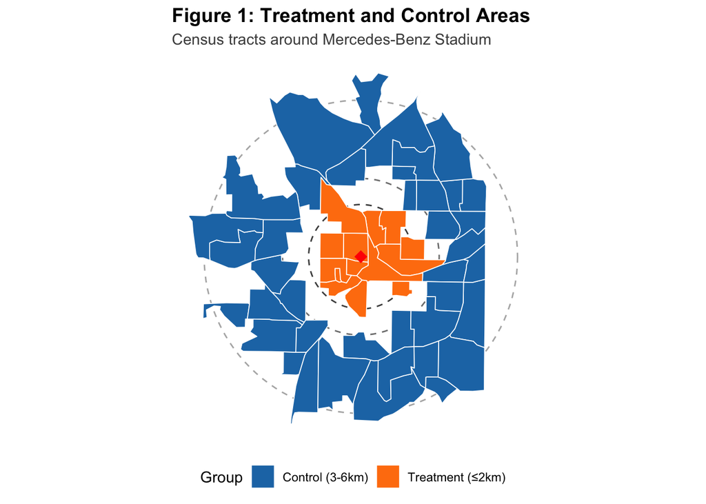

Treatment and control areas around Mercedes-Benz Stadium. Orange tracts (≤2km) form the treatment group, blue tracts (3-6km) form the control group. Stadium location marked with red diamond.

### Descriptive Statistics

```r
crime_panel_prep <- crime_tracts_df %>%
  left_join(tract_distances, by = c("tract_id" = "GEOID")) %>%
  filter(!is.na(treated))

crime_panel_daily <- crime_panel_prep %>%
  group_by(tract_id, date_only, year, month) %>%
  summarize(
    crime_count = n(),
    violent_crime = sum(crime_type %in% c("HOMICIDE", "ROBBERY", "AGG ASSAULT"), na.rm = TRUE),
    property_crime = sum(crime_type %in%
      c("LARCENY-FROM VEHICLE", "LARCENY-NON VEHICLE", "BURGLARY", "AUTO THEFT"), na.rm = TRUE),
    treated = first(treated),
    distance_km = first(distance_km),
    post = first(post),
    .groups = "drop"
  )


crime_panel_with_events <- crime_panel_daily %>%
  left_join(events %>% select(event_date, event_day, event_type, event_timing),
            by = c("date_only" = "event_date")) %>%
  mutate(
    event_day = replace_na(event_day, 0),
    event_type = replace_na(event_type, "No event"),
    soccer_event = if_else(event_type == "Soccer", 1, 0),
    nfl_event = if_else(event_type == "NFL", 1, 0),
    day_game = if_else(event_timing == "Day game", 1, 0, 0),
    night_game = if_else(event_timing == "Night game", 1, 0, 0)
  )


all_dates <- crime_panel_with_events %>% distinct(date_only, year, month, post)
tract_chars <- tract_distances %>% filter(!is.na(treated))

crime_panel_balanced <- crossing(
  tract_id = tract_chars$GEOID,
  date_only = all_dates$date_only
) %>%
  left_join(all_dates, by = "date_only") %>%
  left_join(tract_chars, by = c("tract_id" = "GEOID")) %>%
  left_join(
    crime_panel_with_events %>%
      select(tract_id, date_only, crime_count, violent_crime, property_crime,
             event_day, event_type, event_timing, soccer_event, nfl_event, day_game, night_game),
    by = c("tract_id", "date_only")
  ) %>%
  mutate(
    crime_count = replace_na(crime_count, 0),
    violent_crime = replace_na(violent_crime, 0),
    property_crime = replace_na(property_crime, 0),
    event_day = replace_na(event_day, 0),
    event_type = replace_na(event_type, "No event"),
    soccer_event = replace_na(soccer_event, 0),
    nfl_event = replace_na(nfl_event, 0),
    day_game = replace_na(day_game, 0),
    night_game = replace_na(night_game, 0),
    year_month = paste0(year, "-", sprintf("%02d", month))
  )
```

Table 1 presents summary statistics separately by treatment group and time period. The final balanced panel contains 138,024 tract-day observations across 54 census tracts and 2556 days.

```r
summary_stats <- crime_panel_balanced %>%
  mutate(
    Period = case_when(
      post == 0 ~ "Pre-Treatment (2013-2017)",
      post == 1 & event_day == 0 ~ "Post-Treatment: Regular Days",
      post == 1 & event_day == 1 ~ "Post-Treatment: Event Days"
    ),
    Group = if_else(treated == 1, "Treatment", "Control")
  ) %>%
  group_by(Period, Group) %>%
  summarise(
    `N Tract-Days` = n(),
    `Mean Crime` = mean(crime_count),
    `SD` = sd(crime_count),
    `Mean Violent` = mean(violent_crime),
    `Mean Property` = mean(property_crime),
    .groups = "drop"
  ) %>%
  mutate(
    period_order = case_when(
      str_detect(Period, "Pre-Treatment") ~ 1,
      str_detect(Period, "Regular Days") ~ 2,
      str_detect(Period, "Event Days") ~ 3
    )
  ) %>%
  arrange(period_order, Group) %>%
  select(-period_order)

kable(summary_stats,
      digits = 3,
      caption = "Table 1: Summary Statistics by Treatment Group and Period",
      format = "html") %>%
  kable_styling(bootstrap_options = c("striped", "hover")) %>%
  pack_rows("Pre-Treatment Period", 1, 2) %>%
  pack_rows("Post-Treatment: Regular Days", 3, 4) %>%
  pack_rows("Post-Treatment: Event Days", 5, 6)
```

Table 1: Summary Statistics by Treatment Group and Period

| Period | Group | N Tract-Days | Mean Crime | SD | Mean Violent | Mean Property |
| --- | --- | --- | --- | --- | --- | --- |
| **Pre-Treatment Period** |  |  |  |  |  |  |
| Pre-Treatment (2013-2017) | Control | 67920 | 0.719 | 1.023 | 0.096 | 0.623 |
| Pre-Treatment (2013-2017) | Treatment | 23772 | 0.825 | 1.152 | 0.121 | 0.704 |
| **Post-Treatment: Regular Days** |  |  |  |  |  |  |
| Post-Treatment: Regular Days | Control | 33295 | 0.588 | 0.948 | 0.062 | 0.526 |
| Post-Treatment: Regular Days | Treatment | 11567 | 0.688 | 1.048 | 0.079 | 0.609 |
| **Post-Treatment: Event Days** |  |  |  |  |  |  |
| Post-Treatment: Event Days | Control | 1025 | 1.508 | 0.927 | 0.177 | 1.332 |
| Post-Treatment: Event Days | Treatment | 445 | 1.697 | 1.011 | 0.180 | 1.517 |

Table 1 shows several different patterns. One pattern is that treatment and control areas have similar baseline crime rates in the pre-treatment period (2013-2017), with treatment areas averaging 0.825 daily crimes per tract compared to 0.719 in control areas, which is a difference of around 15%. This suggests reasonable pre-treatment balance between groups.

Another pattern is that during the post-treatment period on regular (non-event) days, both groups have decreases in crime rates. Treatment areas average 0.688 crimes per tract-day while control areas average 0.588, maintaining similar crime patterns to the pre-period.

Furthermore, event days show increased crime rates when compared to regular days. In treatment areas, crime rises from 0.688 on regular days to 1.697 on event days (a 147% increase). Control areas also increase from 0.588 to 1.508 (156% increase). The absolute difference in event-day crime between treatment and control areas (0.189 crimes per day) is larger than the difference on regular days (0.100 crimes).

The data contains a high proportion of zero observations (55.9% overall). Table A1 in the Appendix provides a detailed breakdown of zero-crime days across all 54 census tracts, showing that treatment tracts average 54.1% zeros while control tracts average 56.5% zeros.

**Plot**

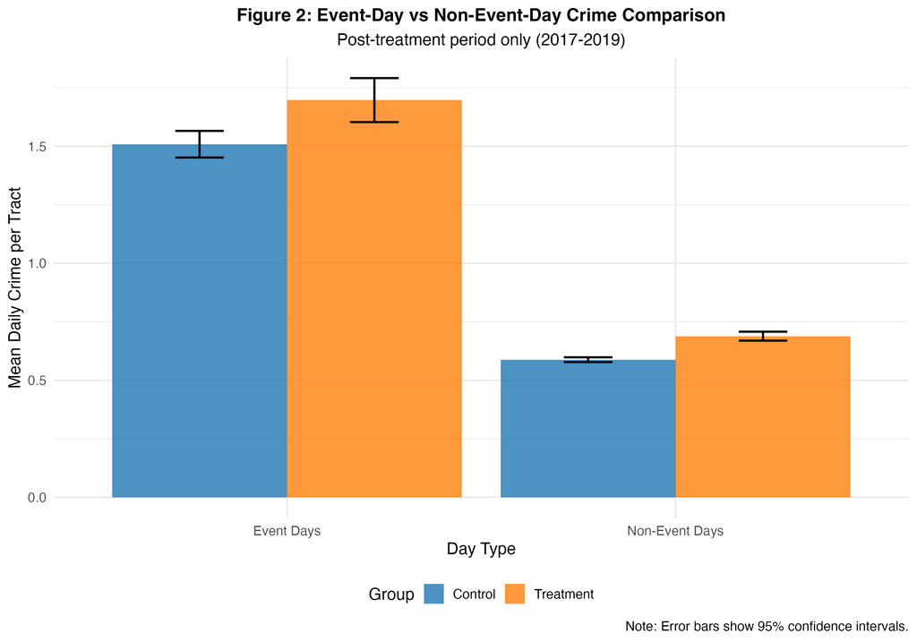

Event-Day vs Non-Event-Day Crime Comparison. Both treatment and control areas experience higher crime on event days, but treatment areas show larger absolute increases.

Figure 2 provides a visual comparison of crime rates on event days versus non-event days in the post-treatment period. Both treatment and control areas experience higher crime on event days, as indicated by the taller bars on the left side of the figure.

## Empirical Strategy

### Difference-in-Differences Framework

I use a two-way fixed effects difference-in-differences model to estimate the causal effect of the stadium opening on local crime. The identifying assumption is the parallel trends assumption, where in the absence of the stadium opening, crime trends in treatment and control areas would have evolved in parallel. I test this assumption by plotting the treatment and control groups, and also conducting an event study.

### Main Specification

My primary estimating equation uses a **triple difference** specification:

$$\begin{aligned}
\text{Crime}_{it} = & \beta_1(\text{Treated}_i \times \text{Post}_t) + \beta_2(\text{Treated}_i \times \text{Event}_t) \\
& + \beta_3(\text{Post}_t \times \text{Event}_t) + \beta_4(\text{Treated}_i \times \text{Post}_t \times \text{Event}_t) \\
& + \alpha_i + \gamma_t + \epsilon_{it}
\end{aligned}$$

where:

- $\text{Crime}_{it}$ is the count of crimes in census tract $i$ on day $t$
- $\text{Treated}_i$ is an indicator for treatment group membership (1 if distance ≤ 2km, 0 if 3-6km)
- $\text{Post}_t$ is an indicator for dates after August 26, 2017
- $\text{Event}_t$ is an indicator for stadium event days (NFL or MLS games)
- $\alpha_i$ are census tract fixed effects
- $\gamma_t$ are year-month fixed effects
- $\epsilon_{it}$ is the error term

The key coefficient of interest is $\beta_4$ (the **triple interaction**), which captures whether event-day crime effects changed differentially for treatment areas after the stadium opened. If $\beta_4$ is near zero and insignificant, this indicates that stadium events did not create localized crime impacts in nearby neighborhoods. The coefficient $\beta_1$ captures the **permanent effect** of the stadium on nearby neighborhoods, which measures the differential change in daily crime in treatment areas in comparison to control areas after the opening. The coefficient $\beta_2$ captures any pre-existing differences in crime between treatment and control areas on event days. The coefficient $\beta_3$ captures whether event-day effects changed city-wide after the stadium opened.

Given that 55.9% of observations contain zero crimes, I estimate **Poisson fixed effects models** as the primary specification, with OLS and binary outcome models (logit and linear probability) for robustness The Poisson model is well-suited for count data with many zeros, as it handles zero values naturally without requiring any data transformations. I cluster standard errors at the census tract level to account for serial correlation within tracts over time. The tract fixed effects $\alpha_i$ absorb time-invariant differences between areas (like baseline crime rate), while the year-month fixed effects $\gamma_t$ absorb common time shocks affecting all of Atlanta (like seasonal patterns or city-wide policy changes).

### Identification

The key identifying assumption is **parallel trends**: in the absence of the stadium opening, treatment and control areas would have experienced the same trajectory of crime rates. I provide two pieces of evidence supporting this claim:

1. **Visual inspection**: I plot pre-treatment trends for both groups (Figure 3) and show they move together
2. **Event study**: I estimate month-by-month treatment effects (Figure 4) to test whether pre-treatment coefficients are statistically distinguishable from zero

The parallel trends assumption would be violated if treatment and control areas were on diverging crime trajectories prior to August 2017, or if other area-specific shocks were also involved with the stadium opening. The visual inspection and event study evidence supports the validity of this assumption.

### Event Study Specification

To examine dynamic treatment effects and provide a visual test of parallel trends, I also estimate an event study model:

$$\text{Crime}_{it} = \sum_{\tau \neq -1} \delta_\tau (\text{Treated}_i \times \mathbb{1}[t = \tau]) + \alpha_i + \gamma_t + \epsilon_{it}$$

where $\tau$ indexes months relative to the stadium opening, with $\tau = -1$ (one month before opening) normalized to zero. The coefficients $\{\delta_\tau\}_{\tau < 0}$ should be statistically indistinguishable from zero if the parallel trends assumption holds. Some month-to-month volatility around zero is expected given the aggregation of daily crime data to monthly averages.

## Results

### Parallel Trends Validation

```r
trends_monthly <- crime_panel_balanced %>%
  mutate(year_month_date = ymd(paste0(year, "-", sprintf("%02d", month), "-01"))) %>%
  group_by(year_month_date, treated) %>%
  summarize(
    mean_crime = mean(crime_count, na.rm = TRUE),
    se_crime = sd(crime_count, na.rm = TRUE) / sqrt(n()),
    .groups = "drop"
  ) %>%
  mutate(
    group = if_else(treated == 1, "Treatment (≤2 km)", "Control (3-6 km)"),
    ci_lower = mean_crime - 1.96 * se_crime,
    ci_upper = mean_crime + 1.96 * se_crime
  )

ggplot(trends_monthly, aes(x = year_month_date, y = mean_crime,
                            color = group, fill = group)) +
  geom_ribbon(aes(ymin = ci_lower, ymax = ci_upper), alpha = 0.15, color = NA) +
  geom_smooth(method = "loess", span = 0.2, se = FALSE, linewidth = 1.5) +
  geom_vline(xintercept = as.numeric(ymd("2017-08-26")),
             linetype = "dashed", color = "#d62728", linewidth = 1.2) +
  annotate("text", x = ymd("2017-08-26"), y = max(trends_monthly$mean_crime) * 0.95,
           label = "Stadium Opens", vjust = -0.3, hjust = -0.05,
           color = "#d62728", size = 4, fontface = "bold") +
  scale_x_date(date_breaks = "6 months", date_labels = "%b\n%Y") +
  scale_color_manual(values = c("Treatment (≤2 km)" = "#ff7f0e",
                                 "Control (3-6 km)" = "#1f77b4")) +
  scale_fill_manual(values = c("Treatment (≤2 km)" = "#ff7f0e",
                                "Control (3-6 km)" = "#1f77b4")) +
  labs(
    title = "Figure 3: Parallel Trends Test",
    x = "Year-Month",
    y = "Average Crime per Tract per Day",
    color = "Distance from Stadium",
    fill = "Distance from Stadium"
  ) +
  theme_minimal() +
  theme(
    legend.position = "bottom",
    plot.title = element_text(hjust = 0.5)
  )
```

**Plot**

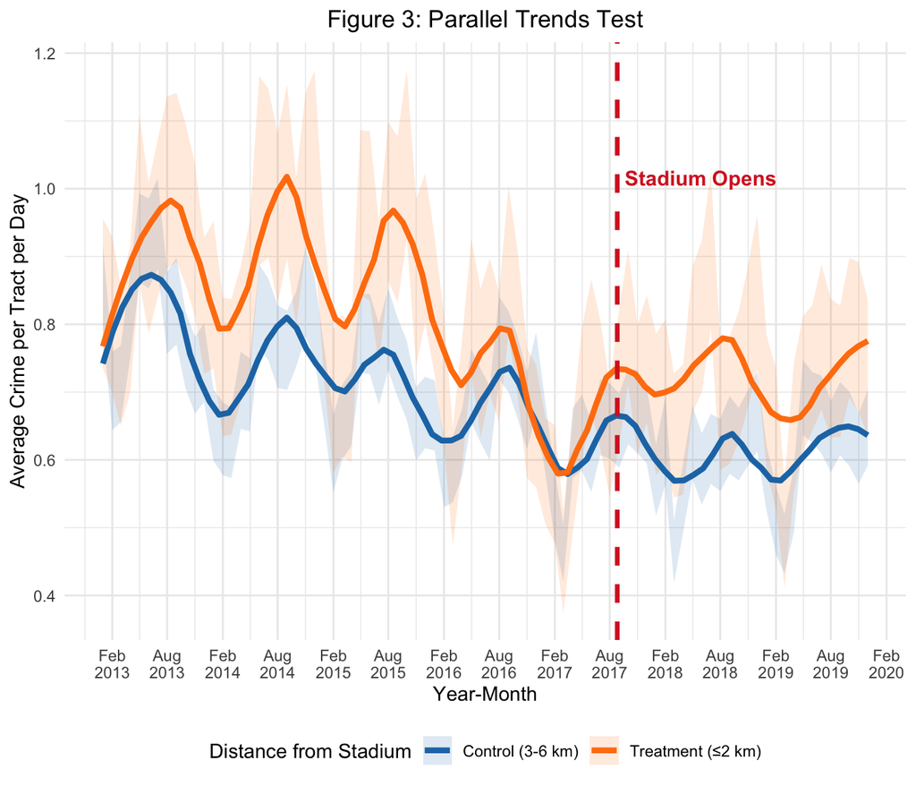

Parallel trends test. Monthly crime rates with 95% confidence intervals (2013-2019). Treatment and control groups follow similar trends before stadium opening.

### Main Results

Table 2 presents the main triple difference results across multiple specifications. Given that 55.9% of observations have zero crimes, I estimate Poisson fixed effects models as the primary specification (Column 2), with OLS (Column 1) and binary outcome models (Columns 3-4) for comparison. The Poisson model works well for count data with many zeros, while the binary models test whether our findings depend on crime happening at all versus how much crime occurs. The main results hold across all approaches.

```r
did_basic <- feols(
  crime_count ~ treated * post | tract_id + year_month,
  data = crime_panel_balanced,
  cluster = ~tract_id
)

did_with_events <- feols(
  crime_count ~ treated * post + treated * event_day | tract_id + year_month,
  data = crime_panel_balanced,
  cluster = ~tract_id
)


triple_diff_ols <- feols(
  crime_count ~ treated * post * event_day | tract_id + year_month,
  data = crime_panel_balanced,
  cluster = ~tract_id
)


pois_basic <- fepois(
  crime_count ~ treated * post | tract_id + year_month,
  data = crime_panel_balanced,
  cluster = ~tract_id
)

pois_with_events <- fepois(
  crime_count ~ treated * post + treated * event_day | tract_id + year_month,
  data = crime_panel_balanced,
  cluster = ~tract_id
)

triple_diff_pois <- fepois(
  crime_count ~ treated * post * event_day | tract_id + year_month,
  data = crime_panel_balanced,
  cluster = ~tract_id
)


crime_panel_balanced <- crime_panel_balanced %>%
  mutate(any_crime = if_else(crime_count > 0, 1, 0))


triple_diff_logit <- feglm(
  any_crime ~ treated * post * event_day | tract_id + year_month,
  data = crime_panel_balanced,
  family = binomial("logit"),
  cluster = ~tract_id
)


triple_diff_lpm <- feols(
  any_crime ~ treated * post * event_day | tract_id + year_month,
  data = crime_panel_balanced,
  cluster = ~tract_id
)

crime_panel_balanced <- crime_panel_balanced %>%
  mutate(
    dow = wday(date_only, label = TRUE),
    dow_num = wday(date_only),
    year_dow = paste0(year, "_", dow),
    month_dow = paste0(month, "_", dow)
  )


triple_diff_dow <- fepois(
  crime_count ~ treated * post * event_day | tract_id + year_month + dow,
  data = crime_panel_balanced,
  cluster = ~tract_id
)


triple_diff_year_dow <- fepois(
  crime_count ~ treated * post * event_day | tract_id + year_month + year_dow,
  data = crime_panel_balanced,
  cluster = ~tract_id
)


triple_diff_month_dow <- fepois(
  crime_count ~ treated * post * event_day | tract_id + year_month + month_dow,
  data = crime_panel_balanced,
  cluster = ~tract_id
)


triple_diff_tract_dow <- fepois(
  crime_count ~ treated * post * event_day | tract_id + year_month + tract_id^dow,
  data = crime_panel_balanced,
  cluster = ~tract_id
)
```

```r
modelsummary(
  list(
    "(1) OLS Triple" = triple_diff_ols,
    "(2) Pois Triple" = triple_diff_pois,
    "(3) Logit Binary" = triple_diff_logit,
    "(4) LPM Binary" = triple_diff_lpm
  ),
  stars = c('*' = .10, '**' = .05, '***' = .01),
  fmt = 4,
  output = "gt",
  coef_rename = c(
    "treated:post" = "Treated × Post",
    "treated:event_day" = "Treated × Event Day",
    "post:event_day" = "Post × Event Day",
    "treated:post:event_day" = "Treated × Post × Event Day (TRIPLE)"
  ),
  gof_omit = "Adj|Within|Pseudo|Log|AIC|BIC|RMSE",
  title = "Table 2: Main Results - Triple Difference Specifications",
  notes = c(
    "Clustered standard errors (by tract) in parentheses.",
    "Data contains 55.9% zero observations.",
    "Column 1: OLS count model. Column 2: Poisson fixed effects (primary).",
    "Columns 3-4: Binary outcome (any crime vs no crime)."
  )
)
```

Table 2: Main Results - Triple Difference Specifications

|  | (1) OLS Triple | (2) Pois Triple | (3) Logit Binary | (4) LPM Binary |
| --- | --- | --- | --- | --- |
| post | 0.0249 | 0.0305 | 0.0350 | 0.0053 |
|  | (0.0524) | (0.0788) | (0.1479) | (0.0299) |
| event_day | 0.7322*** | 0.6917*** | 15.7448*** | 0.5169*** |
|  | (0.0952) | (0.0918) | (0.0325) | (0.0383) |
| Treated × Post | -0.0014 | 0.0239 | 0.0423 | 0.0149 |
|  | (0.0367) | (0.0586) | (0.0779) | (0.0149) |
| Treated × Event Day | -0.2142 | -0.1999 | -0.1093*** | -0.0544 |
|  | (0.2085) | (0.1813) | (0.0248) | (0.0735) |
| Post × Event Day | -0.0506 | -0.0535 | 0.0378 | 0.0068 |
|  | (0.0988) | (0.0903) | (0.0479) | (0.0188) |
| Treated × Post × Event Day (TRIPLE) | 0.2315 | 0.1278 | 0.0076 | -0.0107 |
|  | (0.2102) | (0.1379) | (0.0771) | (0.0223) |
| Num.Obs. | 138024 | 138024 | 138024 | 138024 |
| R2 | 0.272 | 0.153 | 0.159 | 0.190 |
| Std.Errors | by: tract_id | by: tract_id | by: tract_id | by: tract_id |
| FE: tract_id | X | X | X | X |
| FE: year_month | X | X | X | X |

* p < 0.1, ** p < 0.05, *** p < 0.01  
Clustered standard errors (by tract) in parentheses.  
Data contains 55.9% zero observations.  
Column 1: OLS count model. Column 2: Poisson fixed effects (primary).  
Columns 3-4: Binary outcome (any crime vs no crime).

The results show several key findings:

1. **No Permanent Stadium Effect**: The treated × post coefficient is small and statistically insignificant across all specifications, ranging from -0.0014 (OLS) to 0.0423 (logit). This indicates the stadium opening did not cause a sustained change in baseline crime rates in surrounding neighborhoods. Treatment areas experienced no differential change in crime after the stadium opened compared to control areas further away.
2. **City-Wide Event-Day Effects**: The event_day coefficient is large and highly significant across all models: 0.7322*** in OLS, 0.6917*** in Poisson, 15.7448*** in logit (log-odds), and 0.5169*** in LPM. In the preferred Poisson specification, crime increases by approximately 0.69 crimes per census tract on game days throughout the entire study area. The treated × event_day interaction is negative across all specifications (-0.2142 in OLS, -0.1999 in Poisson, -0.1093*** in logit, -0.0544 in LPM), suggesting that if anything, treatment areas experience slightly smaller event-day crime increases than control areas even before the stadium opened. This difference is statistically significant only in the logit model (p < 0.01), which examines whether any crime occurs rather than crime counts. This potentially suggests that the difference may lie in crime occurrence rather than crime volume.
3. **Triple Difference Results**: The triple interaction coefficient (Treated × Post × Event Day) is small and statistically insignificant across all specifications: 0.1278 in Poisson (p = 0.35), 0.2315 in OLS (p = 0.27), 0.0076 in logit (p = 0.92), and -0.0107 in LPM (p = 0.63). This confirms that event-day crime effects did not change differently for treatment areas after the stadium opened, indicating stadium events affect crime across the entire city equally, not just in neighborhoods near the stadium. The post × event_day coefficient is also small and insignificant across models (-0.0506 in OLS, -0.0535 in Poisson, 0.0378 in logit, 0.0068 in LPM), showing that the city-wide event-day effect itself did not change after the stadium opened.
4. **Binary Outcome Robustness**: Columns 3-4 examine whether any crime occurred (rather than counting crimes). The triple interaction remains small and statistically insignificant in both logit (0.0076, p = 0.92) and linear probability models (-0.0107, p = 0.63) as previously mentioned, confirming that results are not driven by the count structure of the data or the high proportion of zeros. The treated × event_day coefficient is negative and significant in the logit model (-0.1093, p < 0.01), showing that treatment areas had smaller event-day crime increases than control areas in the pre-stadium period. This actually makes our test conservative as if we had stadium generated localized effects, we would expect a positive triple interaction showing treatment areas became more responsive to event days post-opening. Instead, the near-zero triple interaction (0.0076) indicates the stadium did not change this pre-existing relationship.
5. **Model Comparison**: Results are remarkably consistent across OLS, Poisson, and binary outcome specifications. Given the 55.9% zero-inflation, Poisson fixed effects (Column 2) serves as the primary specification, though conclusions hold across all approaches. The key finding is that the triple interaction is small and insignificant across all models.

```r
modelsummary(
  list(
    "(1) No DoW" = triple_diff_pois,
    "(2) Basic DoW" = triple_diff_dow,
    "(3) Year×DoW" = triple_diff_year_dow,
    "(4) Month×DoW" = triple_diff_month_dow,
    "(5) Tract×DoW" = triple_diff_tract_dow
  ),
  stars = c('*' = .10, '**' = .05, '***' = .01),
  fmt = 4,
  output = "gt",
  coef_rename = c(
    "treated:post" = "Treated × Post",
    "treated:event_day" = "Treated × Event Day",
    "post:event_day" = "Post × Event Day",
    "treated:post:event_day" = "TRIPLE INTERACTION"
  ),
  gof_omit = "Adj|Within|Pseudo|Log|AIC|BIC|RMSE",
  title = "Table 3: Day-of-Week Fixed Effects Robustness",
  notes = c(
    "All models use Poisson fixed effects.",
    "Clustered standard errors (by tract) in parentheses.",
    "Specifications add increasingly flexible day-of-week controls."
  )
)
```

Table 3: Day-of-Week Fixed Effects Robustness

|  | (1) No DoW | (2) Basic DoW | (3) Year×DoW | (4) Month×DoW | (5) Tract×DoW |
| --- | --- | --- | --- | --- | --- |
| post | 0.0305 | 0.0276 | 0.0385 | 0.0339 | 0.0254 |
|  | (0.0788) | (0.0792) | (0.0796) | (0.0801) | (0.0792) |
| event_day | 0.6917*** | 0.7090*** | 0.7480*** | 0.7353*** | 0.7600*** |
|  | (0.0918) | (0.0902) | (0.0884) | (0.0903) | (0.0907) |
| Treated × Post | 0.0239 | 0.0234 | 0.0229 | 0.0232 | 0.0307 |
|  | (0.0586) | (0.0585) | (0.0584) | (0.0584) | (0.0592) |
| Treated × Event Day | -0.1999 | -0.2004 | -0.2005 | -0.1994 | -0.3466* |
|  | (0.1813) | (0.1824) | (0.1824) | (0.1828) | (0.1870) |
| Post × Event Day | -0.0535 | -0.0302 | -0.0294 | -0.0335 | -0.0350 |
|  | (0.0903) | (0.0903) | (0.0875) | (0.0929) | (0.0895) |
| TRIPLE INTERACTION | 0.1278 | 0.1300 | 0.1324 | 0.1295 | 0.1099 |
|  | (0.1379) | (0.1382) | (0.1376) | (0.1393) | (0.1371) |
| Num.Obs. | 138024 | 138024 | 138024 | 138024 | 136198 |
| R2 | 0.153 | 0.154 | 0.154 | 0.154 |  |
| Std.Errors | by: tract_id | by: tract_id | by: tract_id | by: tract_id | by: tract_id |
| FE: tract_id | X | X | X | X | X |
| FE: year_month | X | X | X | X | X |
| FE: dow |  | X |  |  |  |
| FE: month_dow |  |  |  | X |  |
| FE: year_dow |  |  | X |  |  |
| FE: tract_id^dow |  |  |  |  | X |

* p < 0.1, ** p < 0.05, *** p < 0.01  
All models use Poisson fixed effects.  
Clustered standard errors (by tract) in parentheses.  
Specifications add increasingly flexible day-of-week controls.

Table 3 shows results are robust to day-of-week controls, which account for natural weekly crime patterns. The triple interaction remains insignificant across all specifications, from basic day-of-week fixed effects to flexible tract-specific day-of-week patterns.

Across all five specifications, the key findings remain consistent. The post coefficient (baseline post-period effect for control areas) ranges from 0.0254 to 0.0385 and is statistically insignificant in all models. The treated × post coefficient ranges from 0.0229 to 0.0307 and is also insignificant across all specifications. This confirms that there is no sustained change in baseline crime rates in nearby neighborhoods after the stadium opened.

The event_day coefficient is large, positive, and highly significant across all specifications, ranging from 0.6917*** in the baseline model to 0.7600*** with tract×DoW interactions. The coefficient increases slightly with more flexible day-of-week controls because these controls absorb natural weekend patterns, which in turn isolates the pure event-day effect. This relationship across all models shows that crime is significantly higher on stadium event days, which mostly occur on weekends when crime rates are naturally higher.

Most importantly, the triple interaction coefficient (Treated × Post × Event Day) remains small and statistically insignificant across all specifications, ranging from 0.1099 to 0.1324. This shows that the finding of no differential event-day effects in treatment areas is robust when controlling for day-of-week patterns at different levels of flexibility. This is from simple day-of-week indicators to tract-specific day-of-week effects that allow each census tract to have its own weekly crime pattern.

The treated × event_day coefficient is consistently negative across all models (ranging from -0.1994 to -0.3466), reaching marginal significance only in the most flexible specification (Tract×DoW: -0.3466, p < 0.10). This suggests that, if anything, treatment areas experience smaller event-day crime increases than control areas in the pre-period, which further supports our finding of no localized stadium impacts. The post × event_day coefficient remains small and insignificant (ranging from -0.0294 to -0.0535), indicating no city-wide change in the relationship between event days and crime after the stadium opened.

These results show that neither pre-existing differences between treatment and control areas on event days, and city-wide changes in event-day effects after the stadium opened, confound the main findings of this paper. The consistency of results across increasingly flexible day-of-week specifications provides strong evidence that weekly crime patterns do not drive the finding of no localized stadium impacts on neighborhood crime.

### Dynamic Effects: Event Study Analysis

Figure 4 below shows the event study estimates, plotting coefficients for each month relative to the stadium opening. This gives both a visual test of the parallel trends assumption and also shows how treatment effects evolved over time.

```r
crime_panel_event_study <- crime_panel_balanced %>%
  mutate(
    treatment_date = ymd("2017-08-26"),
    rel_time = interval(treatment_date, date_only) %/% months(1)
  ) %>%
  filter(rel_time >= -24 & rel_time <= 24)


event_study_model <- feols(
  crime_count ~ i(rel_time, treated, ref = -1) | tract_id + year_month,
  data = crime_panel_event_study,
  cluster = ~tract_id
)


iplot(event_study_model,
      main = "Figure 4: Event Study - Treatment Effect Over Time",
      xlab = "Months Relative to Stadium Opening",
      ylab = "Treatment Effect on Crime")
abline(v = -0.5, col = "red", lty = 2)


event_study_coefs <- broom::tidy(event_study_model, conf.int = TRUE) %>%
  filter(str_detect(term, "rel_time")) %>%
  mutate(time = as.numeric(str_extract(term, "-?\\d+")))
```

**Plot**

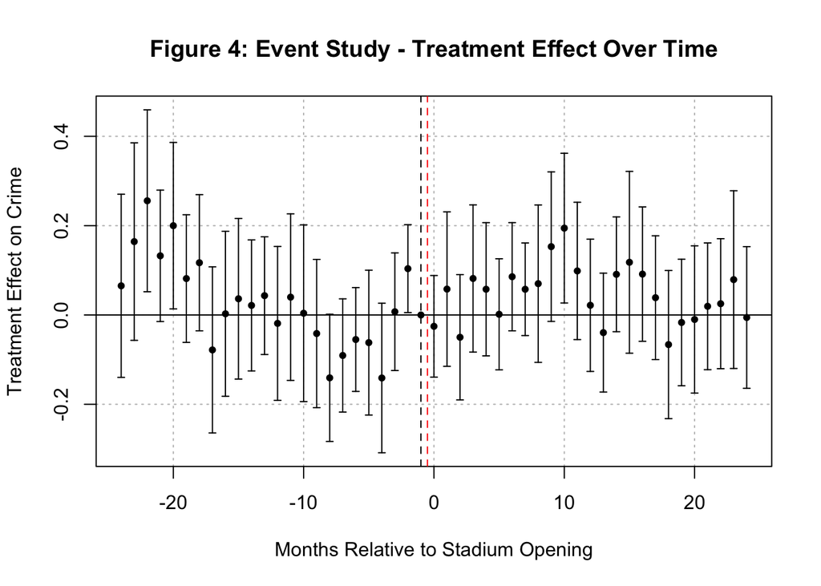

Figure 4: Event Study - Treatment Effect Over Time. Coefficients represent the differential change in crime between treatment and control areas at each month relative to stadium opening (t=0). Reference period is t=-1. Error bars show 95% confidence intervals.

The event study shows that the parallel trends assumption holds and reveals small, noisy treatment effects consistent with the main DiD results.

Pre-Treatment Period (months -24 to -1): Before the stadium opened, the coefficients fluctuate around zero with no clear upward or downward trend. A few individual months show statistical significance, however this is expected when testing many periods, and reflects month-to-month variation rather than an actual trend. The main result is that treatment and control areas weren’t diverging before the stadium opened, which supports the parallel trends assumption.

Interpretation: The event study confirms two key findings. First, parallel trends holds before treatment as there is no pre-existing trend between treatment and control areas. Second, the post-treatment effects are small, noisy, and mostly insignificant, consistent with our DiD results which show no permanent stadium effect (treated × post ≈ 0).

### Robustness Checks

```r
tract_alt1 <- tracts %>%
  mutate(
    centroid = st_centroid(geometry),
    distance_km = as.numeric(st_distance(centroid, stadium_coords)) * 0.3048 / 1000,
    treated = case_when(
      distance_km <= 1.5 ~ 1,
      distance_km > 3.0 & distance_km <= 6.0 ~ 0,
      TRUE ~ NA_real_
    )
  ) %>%
  st_drop_geometry() %>%
  select(GEOID, treated_alt1 = treated)

tract_alt2 <- tracts %>%
  mutate(
    centroid = st_centroid(geometry),
    distance_km = as.numeric(st_distance(centroid, stadium_coords)) * 0.3048 / 1000,
    treated = case_when(
      distance_km <= 2.5 ~ 1,
      distance_km > 4.0 & distance_km <= 7.0 ~ 0,
      TRUE ~ NA_real_
    )
  ) %>%
  st_drop_geometry() %>%
  select(GEOID, treated_alt2 = treated)

crime_panel_alt <- crime_panel_balanced %>%
  left_join(tract_alt1, by = c("tract_id" = "GEOID")) %>%
  left_join(tract_alt2, by = c("tract_id" = "GEOID"))

did_alt1 <- fepois(
  crime_count ~ treated_alt1 * post * event_day | tract_id + year_month,
  data = crime_panel_alt %>% filter(!is.na(treated_alt1)),
  cluster = ~tract_id
)

did_alt2 <- fepois(
  crime_count ~ treated_alt2 * post * event_day | tract_id + year_month,
  data = crime_panel_alt %>% filter(!is.na(treated_alt2)),
  cluster = ~tract_id
)


crime_panel_placebo <- crime_panel_balanced %>%
  filter(post == 0) %>%
  mutate(fake_post = if_else(date_only >= ymd("2016-08-26"), 1, 0))

did_placebo <- feols(
  crime_count ~ treated * fake_post | tract_id + year_month,
  data = crime_panel_placebo,
  cluster = ~tract_id
)

crime_panel_no_transition <- crime_panel_balanced %>%
  filter(!(date_only >= ymd("2017-08-26") & date_only < ymd("2017-09-26")))

did_no_transition <- fepois(
  crime_count ~ treated * post * event_day | tract_id + year_month,
  data = crime_panel_no_transition,
  cluster = ~tract_id
)
```

Table 4 in the Appendix gives additional robustness checks which test the sensitivity of the main findings to alternative specifications. The results demonstrate that findings are robust across different treatment definitions, placebo tests, and sample restrictions.

**Alternative Bandwidth Specifications (Columns 2-3):** The main results hold when we change the geographic definition of treatment. Using a tighter bandwidth (≤1.5km treatment, Column 2), the triple interaction is 0.092 and insignificant (p = 0.62). Using a wider bandwidth (≤2.5km treatment, Column 3), the triple interaction increases slightly to 0.156 but remains insignificant (p = 0.34). In both specifications, the permanent effect (treated × post) is small and insignificant (-0.049 and 0.009, respectively), while event-day effects remain large and significant (0.691*** and 0.594***). The consistency across bandwidths confirms that results are not driven by the specific 2km threshold that is selected for the main analysis.

**Placebo Test (Column 4):** To test whether treatment and control areas were diverging before the stadium opened, I estimate a placebo model using only pre-treatment data (2013-2017) with a fake treatment date of August 26, 2016. The placebo coefficient (treated × fake_post = -0.105, p < 0.10) is marginally significant, indicating a slight differential trend in the pre-period. While not ideal, this small negative coefficient (representing about 0.1 crimes per tract-day) does not seriously threaten the identification strategy for several reasons. The visual inspection of both the parallel trends plot (Figure 3) and event study (Figure 4) shows no obvious systematic divergence. Furthermore, the magnitude is small and only marginally significant. Most importantly, the direction of the trend would bias estimates away from finding harmful stadium effects, meaning our finding of no stadium effect is conservative rather than overstated.

**Transition Period Exclusion (Column 5):** To address concerns about immediate adjustment effects, Column 5 excludes the first month after stadium opening (August 26 - September 26, 2017). Results are nearly identical to the baseline: the triple interaction is 0.154 (p = 0.28), the permanent effect is 0.024 (p = 0.69), and the event-day effect remains 0.692***. This demonstrates that the our findings are not driven by short-term transitional dynamics.

## Conclusion

This paper examines how Mercedes-Benz Stadium’s opening affected crime in nearby Atlanta neighborhoods. I use a triple difference specification with daily crime data ranging from 2013-2019, comparing census tracts within 2 kilometers of the stadium to those 3-6 kilometers away. The design allows us to estimate both permanent neighborhood effects and temporary event-day impacts.

The main finding of this paper is that the stadium didn’t create localized crime problems for nearby neighborhoods. My key result is the triple interaction coefficient, which tests if nearby neighborhoods started seeing worse crime on event days after the stadium opened. In the Poisson specification, this coefficient equals 0.128 (p = 0.35), which is both small in magnitude and statistically insignificant. This shows that stadium events don’t create specific localized crime impacts near the stadium.

Furthermore, several other patterns also appear. There is no permanent effect on nearby neighborhoods. The treated × post coefficient of 0.024 (p = 0.68) shows that areas close to the stadium, didn’t have sustained changes in baseline crime rates after opening. Moreover, stadium events create considerable city-wide crime increases of around 0.69 additional crimes per tract on event days, which is around a 96% increase from baseline rates. Additionally, before the stadium opened, treatment areas didn’t show different event-day crime patterns than control areas (treated × event_day = -0.200, p = 0.27).

A number of different robustness checks have been carried out in this paper. The findings have been tested extensively, to make sure they are real and not just products of modelling decisions. The results hold up across Poisson fixed effects models that account for the 55.9% zero-inflation in the data. They also hold when comparing whether crime occurred at all (binary outcomes), rather than counting crimes. Adding day-of-week controls at four different levels of flexibility doesn’t change these conclusions either. These controls are important to the paper, as stadium events happen mostly on weekends when crime is naturally higher anyway. The findings are also robust to using different distance thresholds for defining treatment areas (≤1.5km or ≤2.5km instead of 2km). A placebo test using a fake treatment date one year early shows a marginally significant negative coefficient of -0.105 (p < 0.10), but this actually strengthens the findings. This means treatment areas had about 0.1 fewer crimes per tract-day before the stadium opened, which would actually bias the analysis against finding localized harmful effects, rather than toward them. The parallel trends plot (Figure 3) and event study (Figure 4) show no obvious systematic divergence, confirming the research design remains valid despite this small pre-trend. The findings are also robust to excluding the immediate transition month after opening. Across all these specifications, the triple interaction remains small and insignificant (ranging from 0.092 to 0.156).

These findings give us important implications in regards to how cities think about stadium development. The main concern for communities is that new stadiums will permanently harm nearby neighborhoods through increased crime. My results suggest these concerns, while understandable, may be overstated. I find no evidence that major sports venues create localized crime effects near the venue. This should provide some reassurance for communities that the distance to a stadium, doesn’t specifically affect neighborhood safety regarding crime.

That said, the city-wide event-day effects present different policy challenges. While there is no localized crime effects on event days, there is increases in crimes across the entire metropolitan area. This matters in regards to how police departments allocate resources. Rather than concentrating officers only around the stadium during events, departments should consider deploying personnel more broadly throughout the city, in relation to the city-wide effects of crime. A 96% increase in crime on event days is substantial, and my results suggest this public safety challenge extends well beyond the stadium’s immediate neighborhood.

While I have addressed questions about localized and city-wide crime effects, several questions still remain for future work. Do these patterns hold for other major stadium openings in different cities? I’ve studied one venue in one city, which may not translate to other cities with different trends and characteristics. Are there different effects for different crime types, or times of day? My analysis aggregates across all crimes and all hours, but the mechanisms still might vary. Does the magnitude of city-wide effects depend on attendance levels, game outcomes, or event characteristics? Understanding all these details would help police departments improve their allocation and deployment strategies for large sporting events.

## References

Billings, S. B., & Depken, C. A. (2011). Sport events and criminal activity: A spatial analysis. In R. T. Jewell (Ed.), Violence and Aggression in Sporting Contests: Economics, History and Policy (pp. 175-187). Springer.

Card, D., & Dahl, G. B. (2011). Family violence and football: The effect of unexpected emotional cues on violent behavior. The Quarterly Journal of Economics, 126(1), 103-143.

Cohen, L. E., & Felson, M. (1979). Social change and crime rate trends: A routine activity approach. American Sociological Review, 44(4), 588-608.

Ellen, I. G., Lacoe, J., & Sharygin, C. A. (2013). Do foreclosures cause crime? Journal of Urban Economics, 74, 59-70.

Kurland, J., Johnson, S. D., & Tilley, N. (2014). Offenses around stadiums: A natural experiment on crime attraction and generation. Journal of Research in Crime and Delinquency, 51(1), 5-28.

MacDonald, J., Klick, J., & Grunwald, B. (2016). The effect of private police on crime: Evidence from a geographic regression discontinuity design. Journal of the Royal Statistical Society: Series A, 179(3), 831-846.

Marie, O. (2016). Police and thieves in the stadium: Measuring the (multiple) effects of football matches on crime. Journal of the Royal Statistical Society: Series A, 179(1), 273-292.

Priks, M. (2015). The effects of surveillance cameras on crime: Evidence from the Stockholm subway. Economic Journal, 125(588), F289-F305.

Rees, D. I., & Schnepel, K. T. (2009). College football games and crime. Journal of Sports Economics, 10(1), 68-87.

Vandeviver, C., Bernasco, W., & Van Daele, S. (2019). Do sports stadiums generate crime on days without matches? A natural experiment on the delayed exploitation of criminal opportunities. Security Journal, 32(1), 1-19.

## Appendix

### Table A1: Zero Inflation Table

```r
zero_summary <- crime_panel_balanced %>%
  group_by(tract_id, treated) %>%
  summarize(
    pct_zero = mean(crime_count == 0) * 100,
    n_days = n(),
    mean_crime = mean(crime_count),
    .groups = "drop"
  ) %>%
  distinct(tract_id, .keep_all = TRUE) %>%  # Ensure uniqueness
  arrange(desc(treated), tract_id)  # FIXED: desc(treated) so 1 comes before 0


n_treatment <- sum(zero_summary$treated == 1)

table_output <- kable(zero_summary,
      col.names = c("Tract ID", "Treatment", "% Zero Days", "N Days", "Mean Daily Crime"),
      caption = "Table A1: Proportion of Zero-Crime Days by Census Tract",
      digits = 2,
      format = "html")

table_output <- kable_styling(table_output,
                              bootstrap_options = c("striped", "hover"),
                              full_width = FALSE)

table_output <- pack_rows(table_output,
                          "Treatment Tracts (≤2km)",
                          1,
                          n_treatment)

table_output <- pack_rows(table_output,
                          "Control Tracts (3-6km)",
                          n_treatment + 1,
                          nrow(zero_summary))

table_output
```

Table A1: Proportion of Zero-Crime Days by Census Tract

| Tract ID | Treatment | % Zero Days | N Days | Mean Daily Crime |
| --- | --- | --- | --- | --- |
| **Treatment Tracts (≤2km)** |  |  |  |  |
| 13121001900 | 1 | 21.44 | 2556 | 1.64 |
| 13121002100 | 1 | 43.39 | 2556 | 0.89 |
| 13121002500 | 1 | 31.46 | 2556 | 1.27 |
| 13121002600 | 1 | 79.46 | 2556 | 0.24 |
| 13121002800 | 1 | 49.88 | 2556 | 0.71 |
| 13121003500 | 1 | 23.04 | 2556 | 1.54 |
| 13121003600 | 1 | 75.31 | 2556 | 0.29 |
| 13121003700 | 1 | 97.54 | 2556 | 0.03 |
| 13121003800 | 1 | 68.31 | 2556 | 0.39 |
| 13121004300 | 1 | 64.16 | 2556 | 0.46 |
| 13121004400 | 1 | 49.49 | 2556 | 0.73 |
| 13121004800 | 1 | 83.49 | 2556 | 0.19 |
| 13121011800 | 1 | 56.46 | 2556 | 0.61 |
| 13121011900 | 1 | 14.08 | 2556 | 2.11 |
| **Control Tracts (3-6km)** |  |  |  |  |
| 13121000200 | 0 | 57.24 | 2556 | 0.57 |
| 13121000400 | 0 | 65.69 | 2556 | 0.44 |
| 13121000500 | 0 | 38.50 | 2556 | 0.99 |
| 13121000600 | 0 | 34.86 | 2556 | 1.17 |
| 13121000700 | 0 | 83.22 | 2556 | 0.19 |
| 13121001100 | 0 | 45.03 | 2556 | 0.84 |
| 13121001201 | 0 | 54.97 | 2556 | 0.62 |
| 13121001300 | 0 | 41.47 | 2556 | 0.90 |
| 13121001400 | 0 | 68.82 | 2556 | 0.38 |
| 13121001500 | 0 | 46.60 | 2556 | 0.79 |
| 13121001600 | 0 | 45.93 | 2556 | 0.79 |
| 13121001700 | 0 | 50.31 | 2556 | 0.70 |
| 13121003000 | 0 | 35.09 | 2556 | 1.11 |
| 13121003100 | 0 | 16.24 | 2556 | 2.06 |
| 13121003200 | 0 | 77.58 | 2556 | 0.25 |
| 13121004000 | 0 | 66.71 | 2556 | 0.43 |
| 13121004100 | 0 | 62.17 | 2556 | 0.50 |
| 13121005000 | 0 | 60.37 | 2556 | 0.52 |
| 13121005200 | 0 | 18.86 | 2556 | 1.77 |
| 13121005300 | 0 | 70.85 | 2556 | 0.37 |
| 13121005501 | 0 | 64.24 | 2556 | 0.47 |
| 13121005502 | 0 | 52.46 | 2556 | 0.67 |
| 13121006000 | 0 | 45.62 | 2556 | 0.82 |
| 13121006100 | 0 | 55.48 | 2556 | 0.59 |
| 13121006200 | 0 | 66.24 | 2556 | 0.42 |
| 13121006300 | 0 | 56.77 | 2556 | 0.57 |
| 13121006400 | 0 | 84.74 | 2556 | 0.17 |
| 13121006500 | 0 | 52.66 | 2556 | 0.67 |
| 13121006601 | 0 | 70.50 | 2556 | 0.37 |
| 13121006602 | 0 | 77.93 | 2556 | 0.26 |
| 13121006700 | 0 | 40.02 | 2556 | 0.97 |
| 13121006801 | 0 | 99.84 | 2556 | 0.00 |
| 13121006900 | 0 | 56.81 | 2556 | 0.58 |
| 13121008101 | 0 | 91.24 | 2556 | 0.09 |
| 13121008301 | 0 | 60.33 | 2556 | 0.54 |
| 13121008302 | 0 | 73.40 | 2556 | 0.31 |
| 13121008400 | 0 | 55.56 | 2556 | 0.59 |
| 13121008500 | 0 | 47.50 | 2556 | 0.77 |
| 13121008902 | 0 | 10.72 | 2556 | 2.53 |
| 13121009101 | 0 | 56.61 | 2556 | 0.59 |

### Table 4: Additional Robustness Checks

```r
modelsummary(
  list(
    "(1) Baseline" = triple_diff_pois,
    "(2) ≤1.5km" = did_alt1,
    "(3) ≤2.5km" = did_alt2,
    "(4) Placebo" = did_placebo,
    "(5) No Transition" = did_no_transition
  ),
  stars = c('*' = .10, '**' = .05, '***' = .01),
  output = "gt",
  coef_rename = c(
    "treated:post" = "Treated × Post",
    "treated_alt1:post" = "Treated × Post",
    "treated_alt2:post" = "Treated × Post",
    "treated:fake_post" = "Treated × Fake Post",
    "treated:event_day" = "Treated × Event Day",
    "treated_alt1:event_day" = "Treated × Event Day",
    "treated_alt2:event_day" = "Treated × Event Day",
    "post:event_day" = "Post × Event Day",
    "treated:post:event_day" = "TRIPLE INTERACTION",
    "treated_alt1:post:event_day" = "TRIPLE INTERACTION",
    "treated_alt2:post:event_day" = "TRIPLE INTERACTION"
  ),
  gof_omit = "Adj|Within|Pseudo|Log|AIC|BIC|RMSE",
  title = "Table 4: Additional Robustness Checks",
  notes = c(
    "All models use Poisson fixed effects and triple difference specification.",
    "Clustered standard errors (by tract) in parentheses.",
    "(1) Baseline: Treatment ≤2km, Control 3-6km",
    "(2) Alternative: Treatment ≤1.5km, Control 3-6km",
    "(3) Alternative: Treatment ≤2.5km, Control 4-7km",
    "(4) Placebo test with fake treatment date (Aug 2016)",
    "(5) Excludes first month after stadium opening",
    "Day-of-week robustness examined in Table 3"
  )
)
```

Table 4: Additional Robustness Checks

|  | (1) Baseline | (2) ≤1.5km | (3) ≤2.5km | (4) Placebo | (5) No Transition |
| --- | --- | --- | --- | --- | --- |
| post | 0.030 | 0.047 | 0.081 |  |  |
|  | (0.079) | (0.079) | (0.095) |  |  |
| event_day | 0.692*** | 0.691*** | 0.594*** |  | 0.692*** |
|  | (0.092) | (0.093) | (0.105) |  | (0.092) |
| Treated × Post | 0.024 | -0.049 | 0.009 |  | 0.024 |
|  | (0.059) | (0.062) | (0.068) |  | (0.060) |
| Treated × Event Day | -0.200 | -0.096 | -0.118 |  | -0.200 |
|  | (0.181) | (0.258) | (0.191) |  | (0.181) |
| Post × Event Day | -0.054 | -0.052 | -0.063 |  | -0.071 |
|  | (0.090) | (0.089) | (0.119) |  | (0.094) |
| TRIPLE INTERACTION | 0.128 | 0.092 | 0.156 |  | 0.154 |
|  | (0.138) | (0.185) | (0.163) |  | (0.143) |
| fake_post |  |  |  | 0.019 |  |
|  |  |  |  | (0.045) |  |
| Treated × Fake Post |  |  |  | -0.105* |  |
|  |  |  |  | (0.057) |  |
| Num.Obs. | 138024 | 122688 | 99684 | 91692 | 136350 |
| R2 | 0.153 | 0.147 | 0.177 | 0.261 | 0.153 |
| Std.Errors | by: tract_id | by: tract_id | by: tract_id | by: tract_id | by: tract_id |
| FE: tract_id | X | X | X | X | X |
| FE: year_month | X | X | X | X | X |

* p < 0.1, ** p < 0.05, *** p < 0.01  
All models use Poisson fixed effects and triple difference specification.  
Clustered standard errors (by tract) in parentheses.  
(1) Baseline: Treatment ≤2km, Control 3-6km  
(2) Alternative: Treatment ≤1.5km, Control 3-6km  
(3) Alternative: Treatment ≤2.5km, Control 4-7km  
(4) Placebo test with fake treatment date (Aug 2016)  
(5) Excludes first month after stadium opening  
Day-of-week robustness examined in Table 3